# Data Science Lecture

Simon Anders

14 October 2019

## 1. Vorlesung (14.10.)

Sorry nochmals für den chaotischen Anfang der Vorlesung. Das mein Laptop so unerwartet den defekt war und ich meine Slides nicht zeigen konnte, hat mich doch sehr aus dem Konzept gebracht. Nächste Woche wird alles klarer und strukturierter werden.

### Inhalte der Vorlesung

In den nächsten Wochen werden wir lernen, mit biologischen und anderebn Daten zu arbeiten: - Rohdaten in eine Form bringen, damit wir damit arbeiten können (“data wrangling”) - Daten plotten (“data visualization”) - Plots und Analysen durchprobieren, um die daten zu erforschen (“exploratory data analysis, EDA”) - Daten und Plots interpretieren - statistisch signifankte Ergebnisse von Zufällen unterscheiden (“inferentielle Statistik”)

### R, Tidyverse und RStudio

Wir verwenden die statistische Programmierumgebung “R”. R is eine Programmiersprache, für die es verschiedene Bedienungs-Oberflächen gibt. Wir verwenden “RStudio”. R ist sehr komplex; wir verwenden daher nur einen Teil von R, das sogenannte “Tidyverse”. Eine gute Einführung zu Tidyverse ist:

Garrett Grolemund and Hadley Wickham: *R for Data Science* online: http://r4ds.had.co.nz/ gedruckt: O’Reilly, 2017; ISBN-13: 978-1491910399

Um zu starten, laden wir zunächst in RStudio das Tidyverse, indem wir diesen Befehl eingeben:

```r
library( tidyverse )
```

(Die daraufhin angezeigten Meldungen sind unwichtig.)

### Beispieldaten für heute

Unsere heutigen Beispieldaten stammen von der [NHANES-Studie](https://www.cdc.gov/nchs/nhanes/index.htm) des Center for Disease Control and Prevention (CDC). Wir verwdnden die Daten von 2015-2016 (Continuous NHANES, data set “I”), and zwar den demographischen Datensatz (“DEMO”) und den “and the”Body Measures“-Datensatz (”BMX“). Wir laden erste die beiden Dateien herunter: [`DEMO_I.XPT`](https://wwwn.cdc.gov/Nchs/Nhanes/2015-2016/DEMO_I.XPT) und [`BMX_I.XPT`](https://wwwn.cdc.gov/Nchs/Nhanes/2015-2016/BMX_I.XPT). (Beide Links können angeklickt werden.) Eine ausführliche Beschreibung findet sich im [“study overview”](https://wwwn.cdc.gov/nchs/nhanes/continuousnhanes/overview.aspx?BeginYear=2015) und in der Dokumentation [zu DEMO](https://wwwn.cdc.gov/Nchs/Nhanes/2015-2016/DEMO_I.htm) und [zu BMX](https://wwwn.cdc.gov/Nchs/Nhanes/2015-2016/BMX_I.htm).

### Laden der Daten in RStudio

Der folgende Befehl, eingetippt in RStudio, lädt die Datei “DEMO_I.XPT”. Damit das funktioniert, muss man vorher im Menü “Session” / “Set workling directory” das Verzeichnis wählen, in dem man die heruntergelandene Datei abgelegt hat. Die Funktion `read_xpt` ist eine spezielle Funktion, die das von NHANES verwendete “XPT”-Datenformat lesen kann.

```r
haven::read_xpt( "DEMO_I.XPT" )
```

```
## # A tibble: 9,971 x 47
##     SEQN SDDSRVYR RIDSTATR RIAGENDR RIDAGEYR RIDAGEMN RIDRETH1 RIDRETH3
##    <dbl>    <dbl>    <dbl>    <dbl>    <dbl>    <dbl>    <dbl>    <dbl>
##  1 83732        9        2        1       62       NA        3        3
##  2 83733        9        2        1       53       NA        3        3
##  3 83734        9        2        1       78       NA        3        3
##  4 83735        9        2        2       56       NA        3        3
##  5 83736        9        2        2       42       NA        4        4
##  6 83737        9        2        2       72       NA        1        1
##  7 83738        9        2        2       11       NA        1        1
##  8 83739        9        2        1        4       NA        3        3
##  9 83740        9        2        1        1       13        2        2
## 10 83741        9        2        1       22       NA        4        4
## # … with 9,961 more rows, and 39 more variables: RIDEXMON <dbl>,
## #   RIDEXAGM <dbl>, DMQMILIZ <dbl>, DMQADFC <dbl>, DMDBORN4 <dbl>,
## #   DMDCITZN <dbl>, DMDYRSUS <dbl>, DMDEDUC3 <dbl>, DMDEDUC2 <dbl>,
## #   DMDMARTL <dbl>, RIDEXPRG <dbl>, SIALANG <dbl>, SIAPROXY <dbl>,
## #   SIAINTRP <dbl>, FIALANG <dbl>, FIAPROXY <dbl>, FIAINTRP <dbl>,
## #   MIALANG <dbl>, MIAPROXY <dbl>, MIAINTRP <dbl>, AIALANGA <dbl>,
## #   DMDHHSIZ <dbl>, DMDFMSIZ <dbl>, DMDHHSZA <dbl>, DMDHHSZB <dbl>,
## #   DMDHHSZE <dbl>, DMDHRGND <dbl>, DMDHRAGE <dbl>, DMDHRBR4 <dbl>,
## #   DMDHREDU <dbl>, DMDHRMAR <dbl>, DMDHSEDU <dbl>, WTINT2YR <dbl>,
## #   WTMEC2YR <dbl>, SDMVPSU <dbl>, SDMVSTRA <dbl>, INDHHIN2 <dbl>,
## #   INDFMIN2 <dbl>, INDFMPIR <dbl>
```

R antwortet auf den Befehl damit, dass es den Anfang der eingelesenen Tabelle ausgibt, die Tabelle aber gleich wieder vergisst. Um die Tabelle zu speichern, muss man sie einer Variablen (d.h., einem Speicherort mit einem Namen) zuweisen. Wir wählen den namen `demo`:

```r
haven::read_xpt( "DEMO_I.XPT" ) -> demo
```

Wir lesen die andere Tabelle ebenso ein:

```r
haven::read_xpt( "BMX_I.XPT" ) -> bmx
```

Die Variablen enthalten nun die Tabellen. Wenn man ihren Namen eingibt, zeigt R den Inhalt an:

```r
bmx
```

```
## # A tibble: 9,544 x 26
##     SEQN BMDSTATS BMXWT BMIWT BMXRECUM BMIRECUM BMXHEAD BMIHEAD BMXHT BMIHT
##    <dbl>    <dbl> <dbl> <dbl>    <dbl>    <dbl>   <dbl>   <dbl> <dbl> <dbl>
##  1 83732        1  94.8    NA       NA       NA      NA      NA  184.    NA
##  2 83733        1  90.4    NA       NA       NA      NA      NA  171.    NA
##  3 83734        1  83.4    NA       NA       NA      NA      NA  170.    NA
##  4 83735        1 110.     NA       NA       NA      NA      NA  161.    NA
##  5 83736        3  55.2    NA       NA       NA      NA      NA  165.    NA
##  6 83737        1  64.4    NA       NA       NA      NA      NA  150     NA
##  7 83738        1  37.2    NA       NA       NA      NA      NA  144.    NA
##  8 83739        1  16.4    NA       NA       NA      NA      NA  102.    NA
##  9 83740        3  10.1    NA       NA        1      NA      NA   NA     NA
## 10 83741        1  76.6    NA       NA       NA      NA      NA  165.    NA
## # … with 9,534 more rows, and 16 more variables: BMXBMI <dbl>,
## #   BMDBMIC <dbl>, BMXLEG <dbl>, BMILEG <dbl>, BMXARML <dbl>,
## #   BMIARML <dbl>, BMXARMC <dbl>, BMIARMC <dbl>, BMXWAIST <dbl>,
## #   BMIWAIST <dbl>, BMXSAD1 <dbl>, BMXSAD2 <dbl>, BMXSAD3 <dbl>,
## #   BMXSAD4 <dbl>, BMDAVSAD <dbl>, BMDSADCM <dbl>
```

## Vorbereiten der Daten

Wir müssen beide Tabellen zusammen fassen (“table join”). Zusammengehörende Zeilen erkennt man daran, dass sie dieselbe Personen-Nummer (“SEQN”) enthalten. Wir fügen die beiden Tabellen mit der `inner_join`-Funktion so zusammen, dass jeweils eine Zeile aus der ersten tabelle und eine Zeile aus der zweiten zusammengefügt werden, wobei zusammengehörige Zeilen daran erkannt werden sollen, dass sie dieselbe Personen-ID (Spalte “SEQN”) enthalten:

```r
inner_join( demo, bmx, by="SEQN")
```

```
## # A tibble: 9,544 x 72
##     SEQN SDDSRVYR RIDSTATR RIAGENDR RIDAGEYR RIDAGEMN RIDRETH1 RIDRETH3
##    <dbl>    <dbl>    <dbl>    <dbl>    <dbl>    <dbl>    <dbl>    <dbl>
##  1 83732        9        2        1       62       NA        3        3
##  2 83733        9        2        1       53       NA        3        3
##  3 83734        9        2        1       78       NA        3        3
##  4 83735        9        2        2       56       NA        3        3
##  5 83736        9        2        2       42       NA        4        4
##  6 83737        9        2        2       72       NA        1        1
##  7 83738        9        2        2       11       NA        1        1
##  8 83739        9        2        1        4       NA        3        3
##  9 83740        9        2        1        1       13        2        2
## 10 83741        9        2        1       22       NA        4        4
## # … with 9,534 more rows, and 64 more variables: RIDEXMON <dbl>,
## #   RIDEXAGM <dbl>, DMQMILIZ <dbl>, DMQADFC <dbl>, DMDBORN4 <dbl>,
## #   DMDCITZN <dbl>, DMDYRSUS <dbl>, DMDEDUC3 <dbl>, DMDEDUC2 <dbl>,
## #   DMDMARTL <dbl>, RIDEXPRG <dbl>, SIALANG <dbl>, SIAPROXY <dbl>,
## #   SIAINTRP <dbl>, FIALANG <dbl>, FIAPROXY <dbl>, FIAINTRP <dbl>,
## #   MIALANG <dbl>, MIAPROXY <dbl>, MIAINTRP <dbl>, AIALANGA <dbl>,
## #   DMDHHSIZ <dbl>, DMDFMSIZ <dbl>, DMDHHSZA <dbl>, DMDHHSZB <dbl>,
## #   DMDHHSZE <dbl>, DMDHRGND <dbl>, DMDHRAGE <dbl>, DMDHRBR4 <dbl>,
## #   DMDHREDU <dbl>, DMDHRMAR <dbl>, DMDHSEDU <dbl>, WTINT2YR <dbl>,
## #   WTMEC2YR <dbl>, SDMVPSU <dbl>, SDMVSTRA <dbl>, INDHHIN2 <dbl>,
## #   INDFMIN2 <dbl>, INDFMPIR <dbl>, BMDSTATS <dbl>, BMXWT <dbl>,
## #   BMIWT <dbl>, BMXRECUM <dbl>, BMIRECUM <dbl>, BMXHEAD <dbl>,
## #   BMIHEAD <dbl>, BMXHT <dbl>, BMIHT <dbl>, BMXBMI <dbl>, BMDBMIC <dbl>,
## #   BMXLEG <dbl>, BMILEG <dbl>, BMXARML <dbl>, BMIARML <dbl>,
## #   BMXARMC <dbl>, BMIARMC <dbl>, BMXWAIST <dbl>, BMIWAIST <dbl>,
## #   BMXSAD1 <dbl>, BMXSAD2 <dbl>, BMXSAD3 <dbl>, BMXSAD4 <dbl>,
## #   BMDAVSAD <dbl>, BMDSADCM <dbl>
```

Wir wählen aus diesen 72 Spalten diejenigen aus, die wir brauchen. Dies geschieht mit `select`. Bei der Gelegenheit ersetzen wir die kryptischen Abkürzungen durch verständlicherer Spalten-Überschriften:

```r
inner_join( demo, bmx, by="SEQN" ) %>%
select(
   subjectId = SEQN,
   age = RIDAGEYR,
   sex = RIAGENDR,
   height = BMXHT,
   weight = BMXWT )
```

```
## # A tibble: 9,544 x 5
##    subjectId   age   sex height weight
##        <dbl> <dbl> <dbl>  <dbl>  <dbl>
##  1     83732    62     1   184.   94.8
##  2     83733    53     1   171.   90.4
##  3     83734    78     1   170.   83.4
##  4     83735    56     2   161.  110.
##  5     83736    42     2   165.   55.2
##  6     83737    72     2   150    64.4
##  7     83738    11     2   144.   37.2
##  8     83739     4     1   102.   16.4
##  9     83740     1     1    NA    10.1
## 10     83741    22     1   165.   76.6
## # … with 9,534 more rows
```

Die Bedeutung der kryptischen Abkürzungen habe ich auf den beiden oben erwähnten Webseiten mit der Tabellen-Dokumentation gefunden.

Das “Pipe-Symbol” “`%>%`” leitet die Daten, die aus der `inner_join`-Funktion “heraus kommen”, an die `select`-Funtion weiter. Wir leiten dies nun gleich weiter an die folgende Funktion, die die ebenso kryptischen numerischen Codes (z.B., 1 für männlich, 2 für weiblich inder Spalte “sex”) durch Wörter ersetzt. Die Zuordnung von Codes zu Wörtern findet sich ebenso in der Dokumntation auf der NHANES-Website.

```r
inner_join( demo, bmx, by="SEQN" ) %>%
select(
   subjectId = SEQN,
   age = RIDAGEYR,
   sex = RIAGENDR,
   height = BMXHT,
   weight = BMXWT,
   ethnicity = RIDRETH3,
   education = DMDEDUC2,
   bornInUS = DMDBORN4 ) %>%
mutate(
  sex = fct_recode( factor(sex), "male"="1", "female"="2" ),
  ethnicity = fct_recode( factor(ethnicity),
    "mexican"="1", "hispanic"="2", "white"="3", "black"="4", "asian"="6", "other"="7" ),
  education = fct_recode( factor(education),
    "below9"="1", "9to11"="2", "high_school"="3", "some_college"="4",
       "college"="5", "dontknow"="9" ),
  bornInUS = fct_recode( factor(bornInUS),
    "yes"="1", "no"="2", "dontknow"="99" )
) ->  nhanes
```

Den komplizierten `mutate`-Befehl besprechen wir nicht weiter; das kommt später.

Hier haben wir nun eine Analyse-Pipeline mit zwei “%>%”-Pipes. Die erste Pipe schiebt die Tabelle von `inner_join` (was die beiden ursprünglichen Tabellen zusammen gefügt hat) zu `select` (was die benötigten Spalten ausgewählt und umbenannt hat) und die zweite `%>%`-Pipe schiebt es zu `mutate`, was die numerischen Codes durch beschreibende Wörter ersetzt. Zuletzt schieben wir das Ergebnis mit `->` in eine Variable namens `nhanes`. Diese enthält nun:

```r
nhanes
```

```
## # A tibble: 9,544 x 8
##    subjectId   age sex    height weight ethnicity education    bornInUS
##        <dbl> <dbl> <fct>   <dbl>  <dbl> <fct>     <fct>        <fct>
##  1     83732    62 male     184.   94.8 white     college      yes
##  2     83733    53 male     171.   90.4 white     high_school  no
##  3     83734    78 male     170.   83.4 white     high_school  yes
##  4     83735    56 female   161.  110.  white     college      yes
##  5     83736    42 female   165.   55.2 black     some_college yes
##  6     83737    72 female   150    64.4 mexican   9to11        no
##  7     83738    11 female   144.   37.2 mexican   <NA>         yes
##  8     83739     4 male     102.   16.4 white     <NA>         yes
##  9     83740     1 male      NA    10.1 hispanic  <NA>         yes
## 10     83741    22 male     165.   76.6 black     some_college yes
## # … with 9,534 more rows
```

## Plotten

Wir laden ein Paket an Zusatz-Funktionen namesn “ggplot2”, das zur Datenvisualisierung dient

```r
library( ggplot2 )
```

Damit können wir nun Daten aus der `nhanes`-Tabelle plotten.

Zum Beispiel können wir die Körpergröße gegen das Alter auftragen:

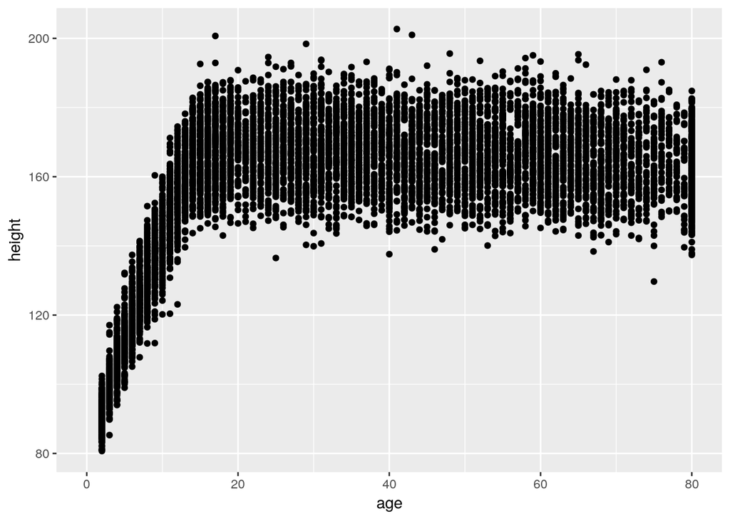

```r
nhanes %>%
ggplot +
  geom_point( aes( x = age, y = height ) )
```

Etwas verfeinert:

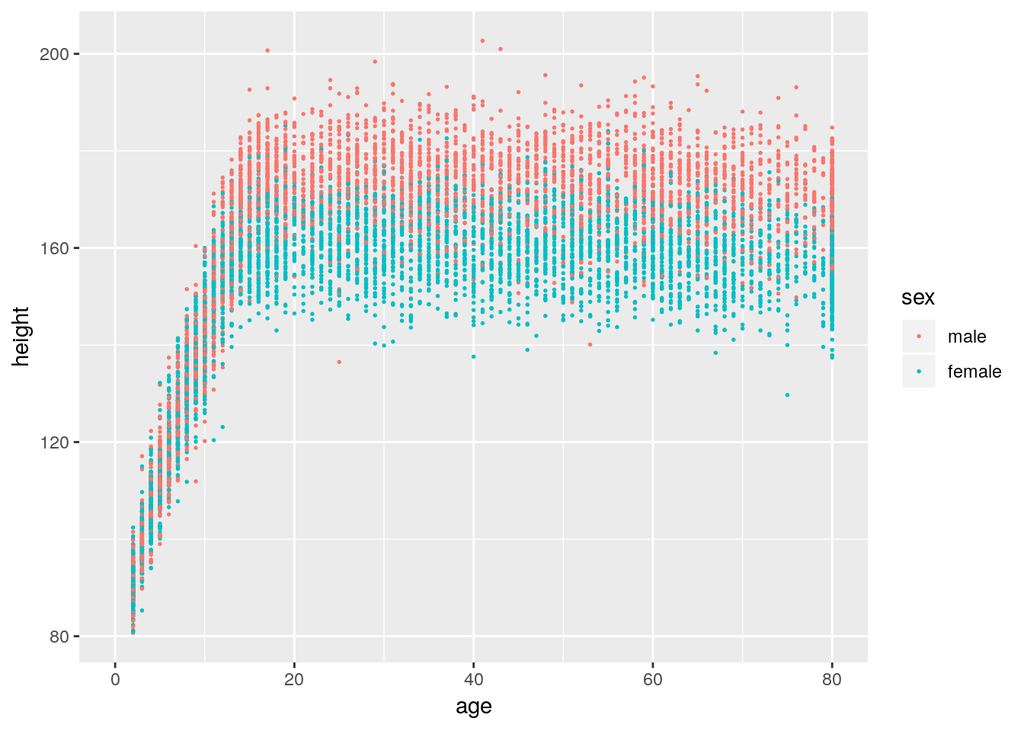

```r
nhanes %>%
ggplot +
  geom_point( aes( x = age, y = height, col=sex ), size=.3 )
```

Hier haben wir unsere Daten-Tabelle (`nhanes`) in die `ggplot`-Funktion geschoben (mit `%>%`) und dann der Plot-Funktion mitgeteilt, was wir plotten möchten: Jede Zeile soll durch einen Punkt (`geom_point`) dargestellt werden, mit `x`- und `y`-Koordinaten, sowie Farbe bestimmt durch die angegebenen Spalten der Tabelle.

Wir können in unsere Analyse-Pipeline auch weitere Schritte einfügen, zum Beispiel einen Filter, damit wir nur die Zeilen behalten, die zu Erwachsenen (Alter mindestens 18) gehören:

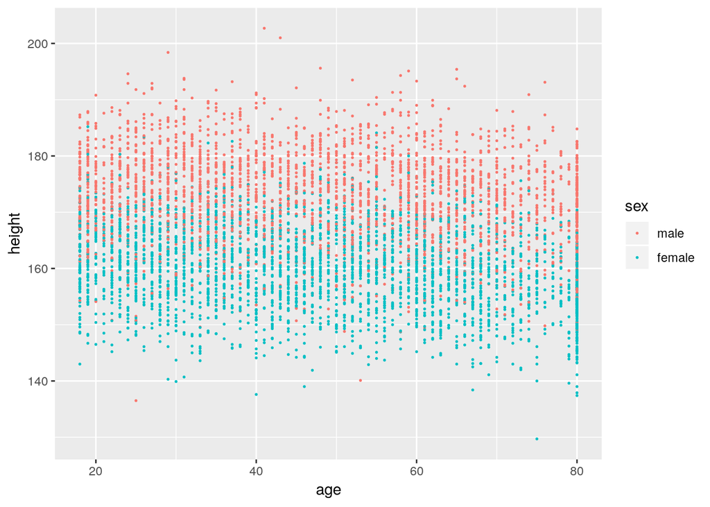

```r
nhanes %>%
filter( age >= 18 ) %>%
ggplot +
  geom_point( aes( x = age, y = height, col=sex ), size=.3 )
```

Wir können auch andere Fragen stellen, z.B. den Zusammenhang aus Körpergröße und Gewicht, hier wieder nur für die Erwachsenen:

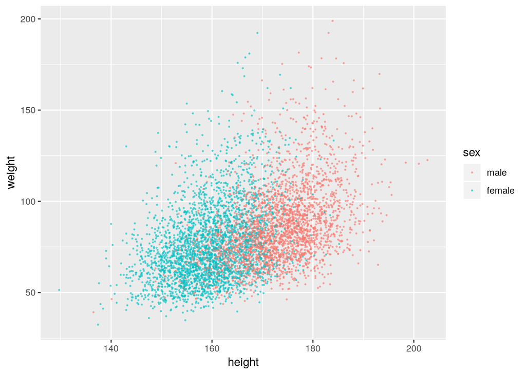

```r
nhanes %>%
filter( age >= 18 ) %>%
ggplot +
  geom_point( aes( x=height, y=weight, col=sex), size=.3, alpha=.5 )
```

Wir könenn auch Rechnung anstellen, zB, den Body Mass Index (BMI) berechnen. Dazu müssen wir das Gewicht in kg durch das Quadrat der Körpergröße in Meter teilen. Um die Körpergröße von cm in m umzurechnen, teilen wir einfach durch 100:

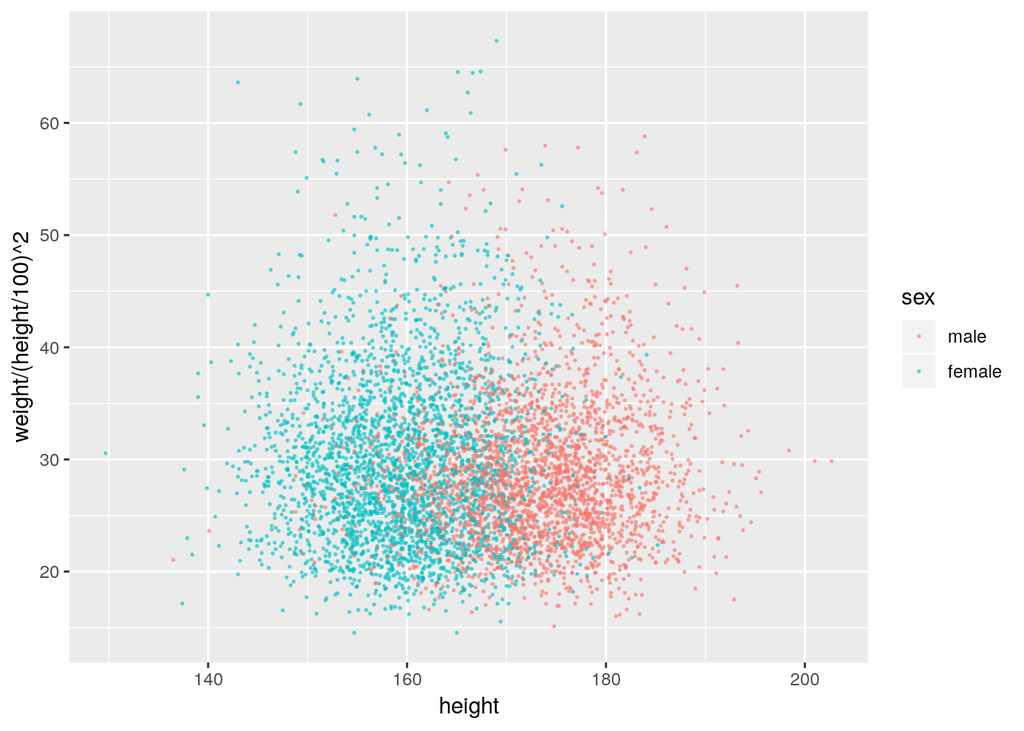

```r
nhanes %>%
filter( age >= 18 ) %>%
ggplot +
  geom_point( aes( x = height, y = weight / (height/100)^2, col = sex), size=.3, alpha=.5 )
```

Als Density-Plot ist das vielleicht aussagekräftiger:

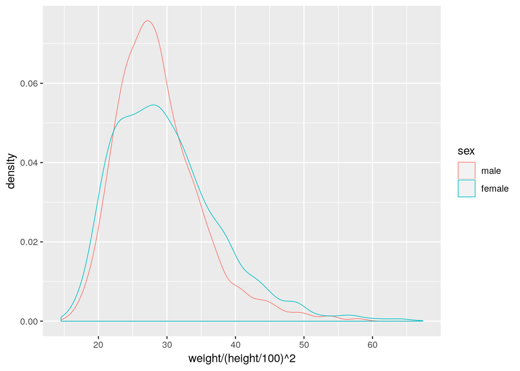

```r
nhanes %>%
filter( age >= 18 ) %>%
ggplot +
  geom_density( aes( x = weight / (height/100)^2, col = sex), size=.3, alpha=.5 )
```

Es gibt noch viele weitere `geom_`-Funktionen. Hier zumbeispiel vertikale Linien (`geom_vline`), um die Grenzen zu Untergewicht (BMI < 18), Übergewicht (BMI > 25) und Adipositas (BMI > 30) zu markieren:

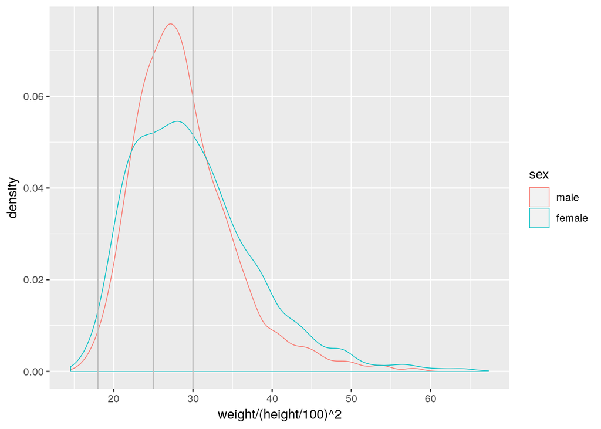

```r
nhanes %>%
filter( age >= 18 ) %>%
ggplot +
  geom_density( aes( x = weight / (height/100)^2, col = sex), size=.3, alpha=.5 ) +
  geom_vline( xintercept = c( 18, 25, 30 ), col="gray" )
```